# Practical Machine Learning Course Project

Esteban Carboni

17/11/2020

## Background

Using devices such as Jawbone Up, Nike FuelBand, and Fitbit it is now possible to collect a large amount of data about personal activity relatively inexpensively. These type of devices are part of the quantified self movement – a group of enthusiasts who take measurements about themselves regularly to improve their health, to find patterns in their behavior, or because they are tech geeks. One thing that people regularly do is quantify how much of a particular activity they do, but they rarely quantify how well they do it. In this project, the goal will be to use data from accelerometers on the belt, forearm, arm, and dumbell of 6 participants. They were asked to perform barbell lifts correctly and incorrectly in 5 different ways. More information is available from the website here: http://web.archive.org/web/20161224072740/http:/groupware.les.inf.puc-rio.br/har (see the section on the Weight Lifting Exercise Dataset).

## Data Preprocessing

First, we import libraries and download the data sets. Then we remove the near zero variables (nZV), columns including more than 90% of NA values. Columns containing ID information are also deleted.

```r
library(caret)
```

```r
download.file("https://d396qusza40orc.cloudfront.net/predmachlearn/pml-training.csv", destfile = "pml-training.csv")
download.file("https://d396qusza40orc.cloudfront.net/predmachlearn/pml-testing.csv", destfile = "pml-testing.csv")

training <- read.csv("pml-training.csv", header = TRUE)
testing <- read.csv("pml-testing.csv", header = TRUE)

nZV <- nearZeroVar(training)
training2 <- training[, -nZV]

mostNA <- sapply(training2, function(x) mean(is.na(x)) > 0.90)
training3 <- training2[, mostNA == FALSE]

training4 <- training3[, -(1:5)]
dim(training4)
```

```
## [1] 19622    54
```

Now the data set has 19622 observations and 54 variables (instead of 160). We make a train-test split, where 70% of the observations will be for training the model.

```r
split  <- createDataPartition(training4$classe, p = 0.7, list = FALSE)
train <- training4[split, ]
test <- training4[-split, ]
```

## Model Evaluation

### Random Forest

Accuracy is very high, so we use this model for making predictions.

```r
set.seed(1740)
RFcontrol <- trainControl(method = "cv",
                          number = 3,
                          verboseIter = FALSE)
RFfit <- train(classe ~ .,
               data = train,
               method = "rf",
               trControl = RFcontrol)

RFpred <- predict(RFfit,
                  newdata = test)
RFCM <- confusionMatrix(table(RFpred,
                              test$classe))

RFCM
```

```
## Confusion Matrix and Statistics
##
##
## RFpred    A    B    C    D    E
##      A 1674    2    0    0    0
##      B    0 1134    3    0    0
##      C    0    3 1022    5    0
##      D    0    0    1  958    0
##      E    0    0    0    1 1082
##
## Overall Statistics
##
##                Accuracy : 0.9975
##                  95% CI : (0.9958, 0.9986)
##     No Information Rate : 0.2845
##     P-Value [Acc > NIR] : < 2.2e-16
##
##                   Kappa : 0.9968
##
##  Mcnemar's Test P-Value : NA
##
## Statistics by Class:
##
##                      Class: A Class: B Class: C Class: D Class: E
## Sensitivity            1.0000   0.9956   0.9961   0.9938   1.0000
## Specificity            0.9995   0.9994   0.9984   0.9998   0.9998
## Pos Pred Value         0.9988   0.9974   0.9922   0.9990   0.9991
## Neg Pred Value         1.0000   0.9989   0.9992   0.9988   1.0000
## Prevalence             0.2845   0.1935   0.1743   0.1638   0.1839
## Detection Rate         0.2845   0.1927   0.1737   0.1628   0.1839
## Detection Prevalence   0.2848   0.1932   0.1750   0.1630   0.1840
## Balanced Accuracy      0.9998   0.9975   0.9972   0.9968   0.9999
```

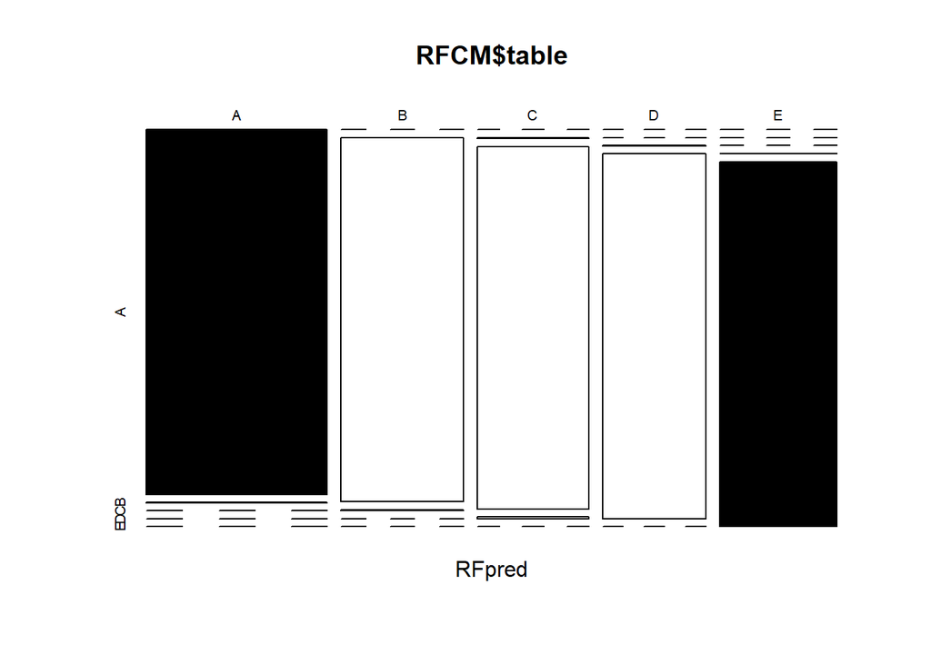

```r
plot(RFCM$table,
     col = RFCM$byClass)
```

## Out of Sample Error

```r
oose <- round(1 - as.numeric(confusionMatrix(table(RFpred, test$classe))$overall[1]), digits = 4)
```

Using cross-validation, we find that out of sample error is 0.0025.

## Data Prediction

We use the model to predict the class of each of the testing observations.

```r
testpred <- predict(RFfit,
                    newdata = testing)
testpred
```

```
##  [1] B A B A A E D B A A B C B A E E A B B B
## Levels: A B C D E
```